# Chapter4: Latitude - Growth Data

Elliott Schmidt

2026-03-20

# Scenario

Within this chapter developmental plasticity was explored within *Acanthochromis polyacanthus* that were collected from two different regions (i.e., low-latitude, Cairns, and high-latitude, Mackay). Fish were held in common garden experiments at 28.5 C. Clutch data was collected along with parental morphometeric data to determine how fish from each population performed at 28.5 C, a temperature that was shown to produce similar absoluate aerobic scope performances in a previous study [link]. Once hatched offspring were placed into three different temperature treatments, 28.5, 30, and 31.5 C. After approximately 5-6 months offspring length and weight was measured, as well as CTmax and respiration during CTmax trials.

# Load packages

```r
library(modelsummary) # descriptive statistics
library(tidyverse) # data manipulation
library(ggpubr) # figure arrangement
library(brms) # Bayesian models
library(StanHeaders)# needed to run Bayesian models
library(rstan) # needed to run Bayesian models
library(standist) # needs to be installed
library(bayesplot) # needed for MCMC diagnostics
library(DHARMa) # model validation
library(ggdist) # partial plots
library(tidybayes) # partial plots
library(broom.mixed) # model investigation
library(emmeans) # pairwise comparisons
library(rstanarm) # pairwise comparisons - need for emmeans
```

# Set working directory

```r
knitr::opts_knit$set(root.dir=working.dir)
```

# Import data

```r
growth <- read_delim("import_files/growth_data.txt",
    delim = "\t", escape_double = FALSE,
    col_types = cols(NOTES = col_skip(),
        ...16 = col_skip(), ...17 = col_skip()),
    trim_ws = TRUE)

clutch_data <- read_delim("import_files/clutch_data_2022_2023.txt",
    delim = "\t", escape_double = FALSE,
    trim_ws = TRUE) %>%
  mutate(CLUTCH_NUMBER = as.factor(CLUTCH_NUMBER))
```

# Data manipulation

```r
density <- count(growth, CLUTCH_NUMBER, TANK) |>
  rename(DENSITY = n) |>
  mutate(CLUTCH_NUMBER = as.factor(CLUTCH_NUMBER),
         TANK = as.factor(TANK))
growth2 <- growth |>
  mutate(CLUTCH_NUMBER = as.factor(CLUTCH_NUMBER),
         MALE = as.factor(MALE),
         FEMALE = as.factor(FEMALE),
         REGION = as.factor(REGION),
         POPULATION = as.factor(POPULATION),
         DATE_OF_HATCH = as.Date(DATE_OF_HATCH, format = "%d/%m/%Y"),
         DATE_SAMPLED = as.Date(DATE_SAMPLED, format = "%d/%m/%Y"),
         DEV_TEMP = as.factor(DEV_TEMP),
         TANK = as.factor(TANK),
         REP = as.factor(REP),
         LENGTH = as.numeric(LENGTH),
         MASS = as.numeric(MASS),
         FULTONK = (1000*MASS)/(LENGTH^3), # Adding FULTON'S K metric
         EXPERIMENT = as.factor(EXPERIMENT)) |>
  full_join(select(clutch_data, c("CLUTCH_NUMBER",
                                   "MALE_STANDARD_LENGTH",
                                   "MALE_MASS",
                                   "MALE_LAT",
                                   "MALE_LONG",
                                   "FEMALE_STANDARD_LENGTH",
                                   "FEMALE_MASS",
                                   "FEMALE_LAT",
                                   "FEMALE_LONG",
                                   "CLUTCH_ORDER",
                                   "DAYS_IN_TREATMENT",
                                   "EGG_COUNT",
                                   "HATCHING_SUCCESS")), by = "CLUTCH_NUMBER") |>
  select(c(1:6,16:27,7:13,15,14)) |>
  drop_na(EXPERIMENT) |>
  mutate(CLUTCH_ORDER = as.factor(CLUTCH_ORDER),
         EXP_GROUP = as.factor(paste0(REGION,"_",DEV_TEMP))) |>
  inner_join(density, by=c("CLUTCH_NUMBER","TANK")) |>
  mutate(TANK = as.numeric(as.character(TANK)),
         LEVEL = as.factor(case_when(TANK >= 1 & TANK <= 199 ~ 1,
                           TANK >= 200 & TANK <= 299 ~ 2,
                           TANK >= 300 & TANK <= 399 ~ 3,
                           TRUE ~ NA_real_))) |>
  mutate(TANK = as.factor(TANK))

save(growth2, file ="./import_files/growth2.RData")
```

# Exploratory data analysis

## LENGTH VS. MASS

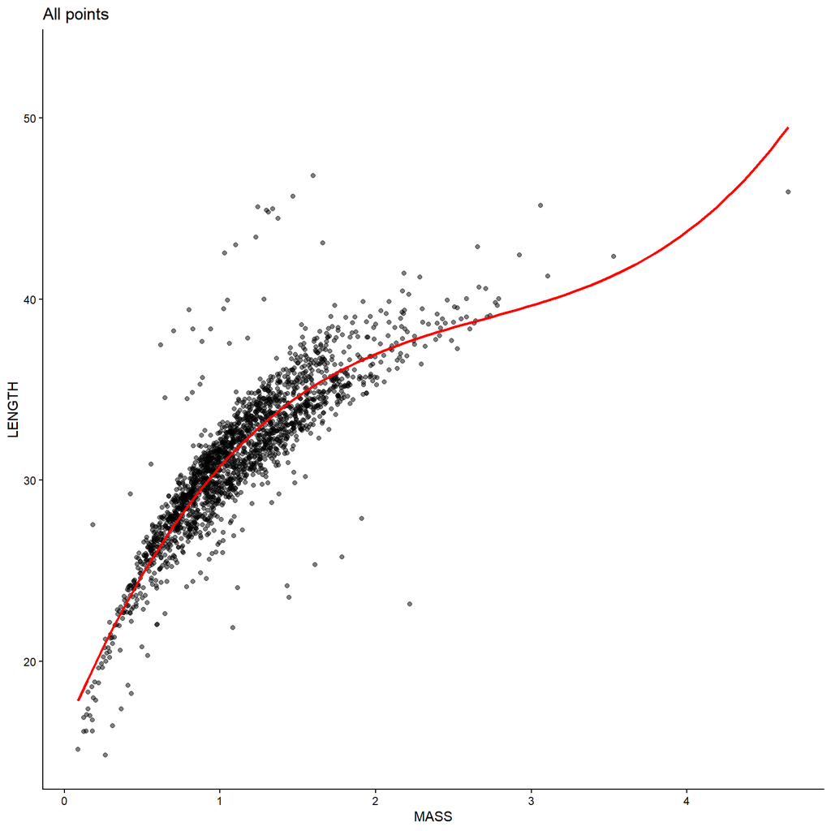

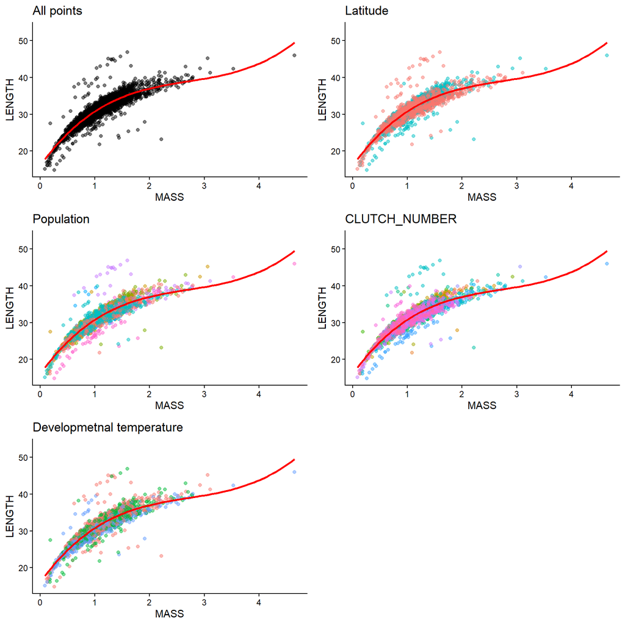

## GROUP COMPARISONS

**NOTE:** On some of the figures ylimits have been set and therefore outliers are hidden

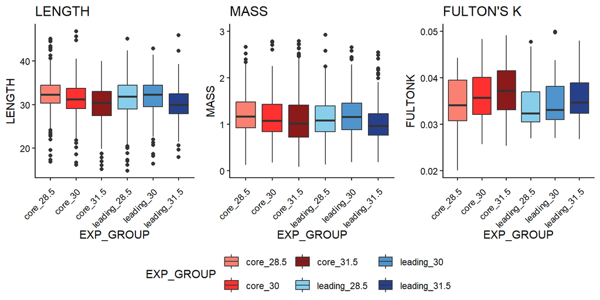

## distribution

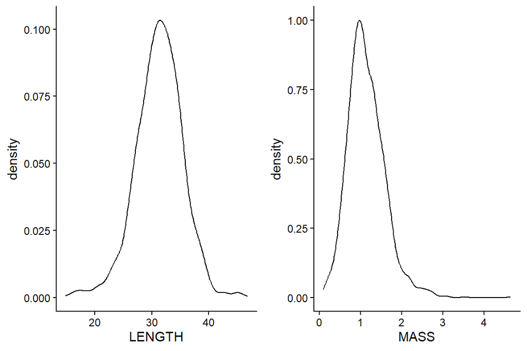

## Parent mass and length

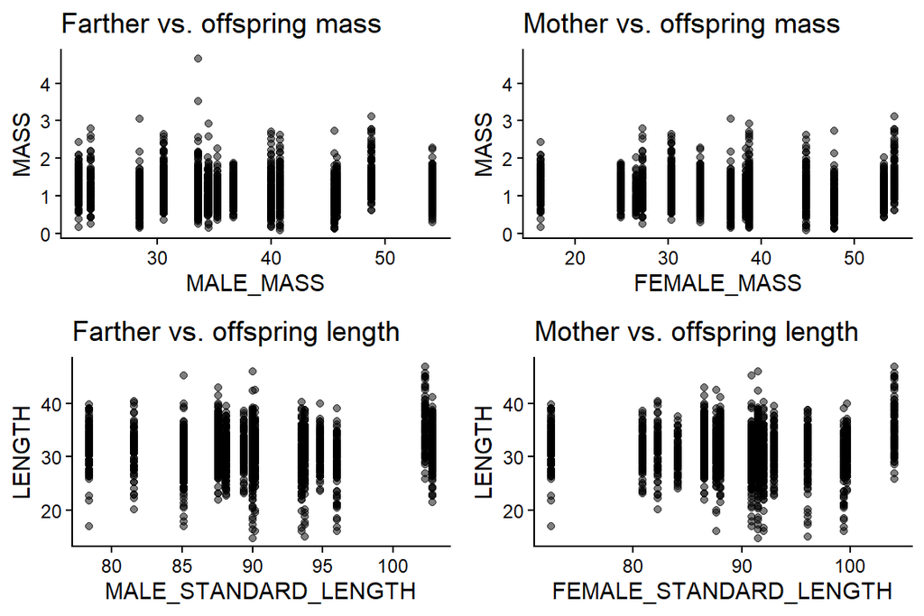

```r
male.mass.plot <- ggplot(growth2, aes(x=MALE_MASS, y=MASS)) +
  geom_point(alpha = 0.5) +
  ggtitle("Farther vs. offspring mass") +
  theme_classic()

female.mass.plot <- ggplot(growth2, aes(x=FEMALE_MASS, y=MASS)) +
  geom_point(alpha = 0.5) +
  ggtitle("Mother vs. offspring mass") +
  theme_classic()

male.length.plot <- ggplot(growth2, aes(x=MALE_STANDARD_LENGTH, y=LENGTH)) +
  geom_point(alpha = 0.5) +
  ggtitle("Farther vs. offspring length") +
  theme_classic()

female.length.plot <- ggplot(growth2, aes(x=FEMALE_STANDARD_LENGTH, y=LENGTH)) +
  geom_point(alpha = 0.5) +
  ggtitle("Mother vs. offspring length") +
  theme_classic()

ggarrange(male.mass.plot, female.mass.plot, male.length.plot, female.length.plot,
          ncol=2,
          nrow=2)
```

# {-}

# Removal of outliers

There seems to be three areas that standout as potentially possessing outliers:

1. The single individual that is >4 grams. This individual is more than double the size of the average individual.
2. The cluster of individuals between 1 and 2grams that are below ~25 mm. Also there is no observable trend in this points (i.e., they are not all form the same developmental temperature, clutch, or population, which could have explained why they performed differently).
3. Individuals that are floating above the main cluster. These could be individuals that grew rapidly and outcompeted diblings in their tank, or perhaps their tank had low density to begin with.

```r
growth3 <- growth2 |>
  filter(MASS < 4, na.rm=TRUE,
         FULTONK < 0.079,
         FULTONK > 0.01,
         DENSITY > 3)
```

# Descriptive statistics

```r
MinMax <- function(x) paste0('[', min(x, na.rm = TRUE), ', ', max(x, na.rm = TRUE), ']')
Range <- function(x) max(x, na.rm = TRUE) - min(x, na.rm = TRUE)

datasummary(REGION *(LENGTH + MASS) + (LENGTH + MASS) ~  N + mean + MinMax + Range + Histogram, data=growth3)
```

| REGION |  | N | mean | MinMax | Range | Histogram |
| --- | --- | --- | --- | --- | --- | --- |
| core | LENGTH | 990 | 31.34 | [15.15, 46.82] | 31.67 | ▁▃▆▇▄▁ |
|  | MASS | 990 | 1.15 | [0.0882, 3.106] | 3.02 | ▁▃▇▇▅▂▁ |
| leading | LENGTH | 971 | 31.29 | [16.16, 45.17] | 29.01 | ▁▃▆▇▅▂ |
|  | MASS | 971 | 1.12 | [0.138, 3.528] | 3.39 | ▁▄▇▅▃▁ |
|  | LENGTH | 1961 | 31.32 | [15.15, 46.82] | 31.67 | ▁▃▆▇▄▁ |
|  | MASS | 1961 | 1.14 | [0.0882, 3.528] | 3.44 | ▁▃▇▅▃▁ |

```r
datasummary(REGION * DEV_TEMP * (LENGTH + MASS) + (LENGTH + MASS) ~  N + median + MinMax + Range + Histogram,
            data=growth3)
```

| REGION | DEV_TEMP |  | N | median | MinMax | Range | Histogram |
| --- | --- | --- | --- | --- | --- | --- | --- |
| core | 28.5 | LENGTH | 337 | 32.30 | [16.9, 45.09] | 28.19 | ▁▂▄▇▄▂ |
|  |  | MASS | 337 | 1.17 | [0.1226, 3.106] | 2.98 | ▂▅▇▅▂▁ |
|  | 30 | LENGTH | 331 | 31.29 | [16.15, 46.82] | 30.67 | ▁▃▇▇▂▁ |
|  |  | MASS | 331 | 1.07 | [0.1778, 2.7827] | 2.60 | ▁▂▇▇▅▃▁ |
|  | 31.5 | LENGTH | 322 | 30.42 | [15.15, 40.03] | 24.88 | ▁▂▄▆▇▅▃▁ |
|  |  | MASS | 322 | 1.02 | [0.0882, 2.79] | 2.70 | ▁▅▇▇▅▃▂▁▁▁ |
| leading | 28.5 | LENGTH | 332 | 31.95 | [16.16, 45.17] | 29.01 | ▁▂▆▇▅▂ |
|  |  | MASS | 332 | 1.09 | [0.138, 3.06] | 2.92 | ▁▃▇▆▅▃ |
|  | 30 | LENGTH | 333 | 32.35 | [16.43, 42.88] | 26.45 | ▁▁▄▆▇▄▁ |
|  |  | MASS | 333 | 1.16 | [0.3081, 2.6554] | 2.35 | ▁▄▇▇▇▅▂▁ |
|  | 31.5 | LENGTH | 306 | 30.01 | [17.98, 42.35] | 24.37 | ▁▃▇▅▄▁▁ |
|  |  | MASS | 306 | 0.97 | [0.1854, 3.528] | 3.34 | ▁▅▇▃▁ |
|  |  | LENGTH | 1961 | 31.45 | [15.15, 46.82] | 31.67 | ▁▃▆▇▄▁ |
|  |  | MASS | 1961 | 1.08 | [0.0882, 3.528] | 3.44 | ▁▃▇▅▃▁ |

```r
growth3 |>
  group_by(REGION, DEV_TEMP) |>
  summarise(n_tanks =n_distinct(FEMALE))
```

```
## `summarise()` has regrouped the output.
## ℹ Summaries were computed grouped by REGION and DEV_TEMP.
## ℹ Output is grouped by REGION.
## ℹ Use `summarise(.groups = "drop_last")` to silence this message.
## ℹ Use `summarise(.by = c(REGION, DEV_TEMP))` for per-operation grouping
##   (`?dplyr::dplyr_by`) instead.
```

| REGION | DEV_TEMP | n_tanks |
| --- | --- | --- |
| core | 28.5 | 10 |
| core | 30 | 10 |
| core | 31.5 | 10 |
| leading | 28.5 | 5 |
| leading | 30 | 5 |
| leading | 31.5 | 5 |

```r
growth3 |>
  group_by(REGION, DEV_TEMP) |>
  summarise(n_tanks =n_distinct(TANK))
```

```
## `summarise()` has regrouped the output.
## ℹ Summaries were computed grouped by REGION and DEV_TEMP.
## ℹ Output is grouped by REGION.
## ℹ Use `summarise(.groups = "drop_last")` to silence this message.
## ℹ Use `summarise(.by = c(REGION, DEV_TEMP))` for per-operation grouping
##   (`?dplyr::dplyr_by`) instead.
```

| REGION | DEV_TEMP | n_tanks |
| --- | --- | --- |
| core | 28.5 | 19 |
| core | 30 | 19 |
| core | 31.5 | 20 |
| leading | 28.5 | 18 |
| leading | 30 | 18 |
| leading | 31.5 | 17 |

note this also removes NA’s therefore the difference in data frames is 21 row:

- 1 datum point with MASS greater than 4
- 1 datum point with high value (removed via FULTONK being less than 0.01)
- 2 data points where the tank density was 2
- 9 data points with low values (removed via FULTONK being greater than 0.079)
- 8 NA’s removed
- **Total: 21**

Now Let’s look at out plots again

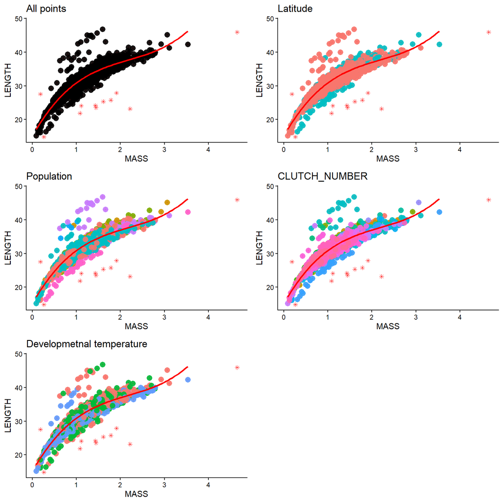

# Fit model [random factors]

First we will place random factors only within out model and see if they do a good job explaining the variance within our model. We will also be include piors which will be based off of out length data.

## Model-1

### Prior investigation

```r
growth3 |>
  group_by(REGION,DEV_TEMP) |>
  summarise(mean(na.omit(LENGTH)),
            sd(na.omit(LENGTH)))
```

```
## `summarise()` has regrouped the output.
## ℹ Summaries were computed grouped by REGION and DEV_TEMP.
## ℹ Output is grouped by REGION.
## ℹ Use `summarise(.groups = "drop_last")` to silence this message.
## ℹ Use `summarise(.by = c(REGION, DEV_TEMP))` for per-operation grouping
##   (`?dplyr::dplyr_by`) instead.
```

| REGION | DEV_TEMP | mean(na.omit(LENGTH)) | sd(na.omit(LENGTH)) |
| --- | --- | --- | --- |
| core | 28.5 | 32.46178 | 4.182013 |
| core | 30 | 31.33622 | 3.898145 |
| core | 31.5 | 30.18239 | 4.401018 |
| leading | 28.5 | 31.60271 | 4.214717 |
| leading | 30 | 31.96679 | 3.908585 |
| leading | 31.5 | 30.20092 | 3.577922 |

### Priors

```r
model.re.formula <- bf(LENGTH ~ 1 + (1|LEVEL/TANK) + (1|POPULATION) + (1|FEMALE))
get_prior(model.re.formula, data=growth3)
```

| prior | class | coef | group | resp | dpar | nlpar | lb | ub | tag | source |
| --- | --- | --- | --- | --- | --- | --- | --- | --- | --- | --- |
| student_t(3, 31.4, 3.8) | Intercept |  |  |  |  |  |  |  |  | default |
| student_t(3, 0, 3.8) | sd |  |  |  |  |  | 0 |  |  | default |
|  | sd |  | FEMALE |  |  |  |  |  |  | default |
|  | sd | Intercept | FEMALE |  |  |  |  |  |  | default |
|  | sd |  | LEVEL |  |  |  |  |  |  | default |
|  | sd | Intercept | LEVEL |  |  |  |  |  |  | default |
|  | sd |  | LEVEL:TANK |  |  |  |  |  |  | default |
|  | sd | Intercept | LEVEL:TANK |  |  |  |  |  |  | default |
|  | sd |  | POPULATION |  |  |  |  |  |  | default |
|  | sd | Intercept | POPULATION |  |  |  |  |  |  | default |

[output cut: 1 more lines]

```r
growth.priors <- prior(normal(31.4, 1.5), class="Intercept") +
  prior(student_t(3, 0, 4.4), class = "sigma")
```

### Model-1

```r
model.re <- brm(model.re.formula,
              data = growth3,
              prior = growth.priors,
              warmup = 500,
              iter = 5000,
              seed=123,
              cores=2,
              save_pars = save_pars(all=TRUE),
              sample_prior = "yes",
              chains = 2,
              thin = 5,
              control = list(adapt_delta=0.95))
prior_summary(model.re)
```

| prior | class | coef | group | resp | dpar | nlpar | lb | ub | source |
| --- | --- | --- | --- | --- | --- | --- | --- | --- | --- |
| normal(31.4, 1.5) | Intercept |  |  |  |  |  |  |  | user |
| student_t(3, 0, 3.8) | sd |  |  |  |  |  | 0 |  | default |
|  | sd |  | FEMALE |  |  |  |  |  | default |
|  | sd | Intercept | FEMALE |  |  |  |  |  | default |
|  | sd |  | LEVEL |  |  |  |  |  | default |
|  | sd | Intercept | LEVEL |  |  |  |  |  | default |
|  | sd |  | LEVEL:TANK |  |  |  |  |  | default |
|  | sd | Intercept | LEVEL:TANK |  |  |  |  |  | default |
|  | sd |  | POPULATION |  |  |  |  |  | default |
|  | sd | Intercept | POPULATION |  |  |  |  |  | default |

[output cut: 1 more lines]

```r
saveRDS(model.re, file="./01.growth_data_analysis_files/model.re.length.RDS")
```

### model validation [random factors]

```r
stan_trace(model.re$fit)
```

```
## 'pars' not specified. Showing first 10 parameters by default.
```

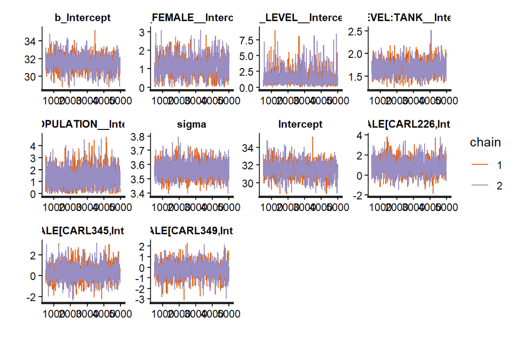

```r
stan_ac(model.re$fit)
```

```
## 'pars' not specified. Showing first 10 parameters by default.
```

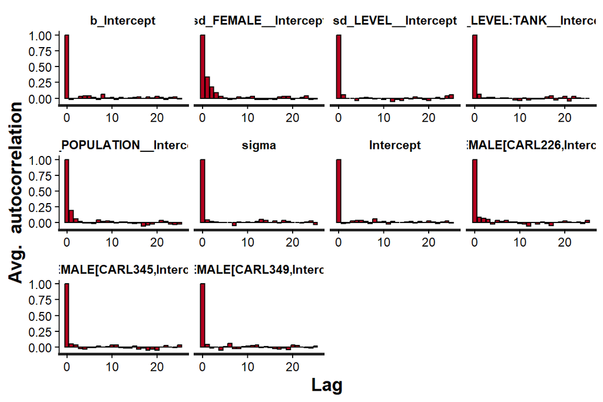

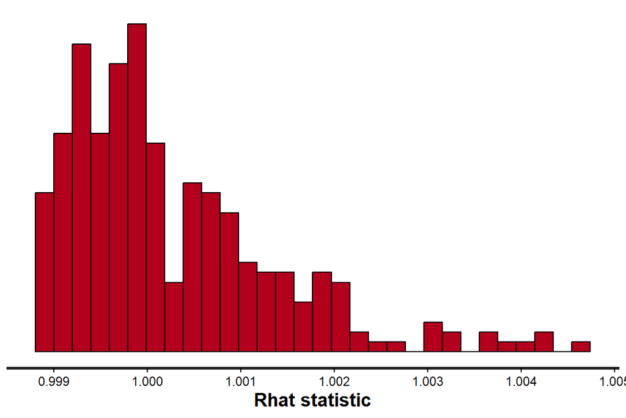

```r
stan_rhat(model.re$fit)
```

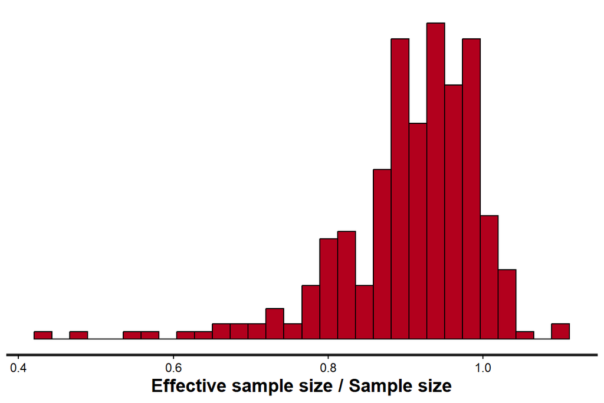

```r
stan_ess(model.re$fit)
```

```r
stan_dens(model.re$fit, separate_chains = TRUE)
```

```
## 'pars' not specified. Showing first 10 parameters by default.
```

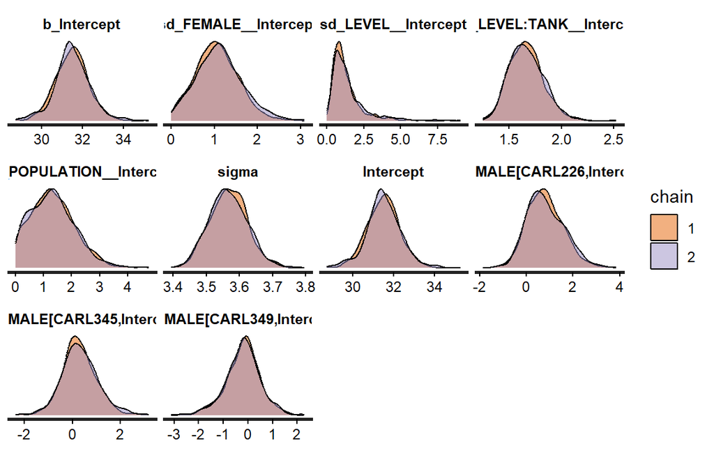

## Model-2

### Priors

```r
model.re0.2.formula <- bf(LENGTH ~ 1 + (1|TANK) + (1|FEMALE))
get_prior(model.re.formula, data=growth3)
```

| prior | class | coef | group | resp | dpar | nlpar | lb | ub | tag | source |
| --- | --- | --- | --- | --- | --- | --- | --- | --- | --- | --- |
| student_t(3, 31.4, 3.8) | Intercept |  |  |  |  |  |  |  |  | default |
| student_t(3, 0, 3.8) | sd |  |  |  |  |  | 0 |  |  | default |
|  | sd |  | FEMALE |  |  |  |  |  |  | default |
|  | sd | Intercept | FEMALE |  |  |  |  |  |  | default |
|  | sd |  | LEVEL |  |  |  |  |  |  | default |
|  | sd | Intercept | LEVEL |  |  |  |  |  |  | default |
|  | sd |  | LEVEL:TANK |  |  |  |  |  |  | default |
|  | sd | Intercept | LEVEL:TANK |  |  |  |  |  |  | default |
|  | sd |  | POPULATION |  |  |  |  |  |  | default |
|  | sd | Intercept | POPULATION |  |  |  |  |  |  | default |

[output cut: 1 more lines]

```r
growth.priors <- prior(normal(31.4, 1.5), class="Intercept") +
  prior(student_t(3, 0, 4.4), class = "sigma")
```

### Model-2

```r
model.re0.2 <- brm(model.re0.2.formula,
              data = growth3,
              prior = growth.priors,
              warmup = 500,
              iter = 5000,
              seed=123,
              cores=2,
              save_pars = save_pars(all=TRUE),
              sample_prior = "yes",
              chains = 2,
              thin = 5,
              control = list(adapt_delta=0.95))
prior_summary(model.re0.2)
```

| prior | class | coef | group | resp | dpar | nlpar | lb | ub | source |
| --- | --- | --- | --- | --- | --- | --- | --- | --- | --- |
| normal(31.4, 1.5) | Intercept |  |  |  |  |  |  |  | user |
| student_t(3, 0, 3.8) | sd |  |  |  |  |  | 0 |  | default |
|  | sd |  | FEMALE |  |  |  |  |  | default |
|  | sd | Intercept | FEMALE |  |  |  |  |  | default |
|  | sd |  | TANK |  |  |  |  |  | default |
|  | sd | Intercept | TANK |  |  |  |  |  | default |
| student_t(3, 0, 4.4) | sigma |  |  |  |  |  | 0 |  | user |

```r
saveRDS(model.re, file="./01.growth_data_analysis_files/model.re0.2.length.RDS")
```

### model validation

```r
stan_trace(model.re0.2 $fit)
```

```
## 'pars' not specified. Showing first 10 parameters by default.
```

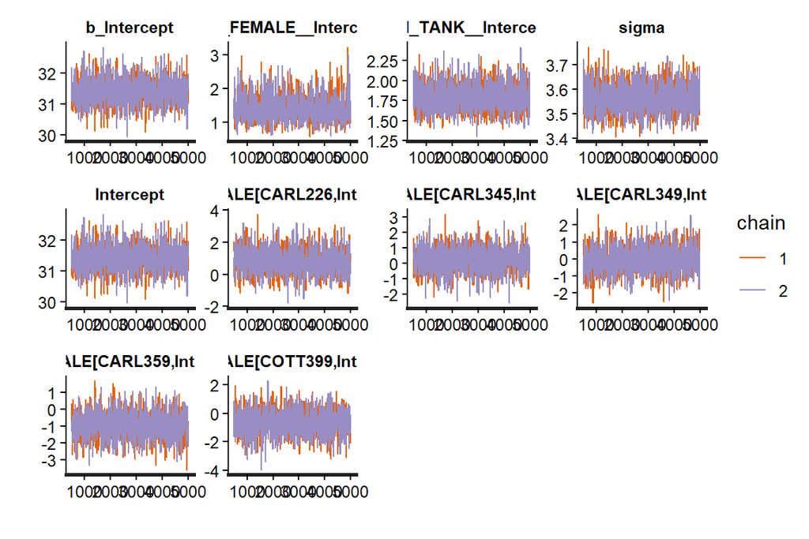

```r
stan_ac(model.re0.2 $fit)
```

```
## 'pars' not specified. Showing first 10 parameters by default.
```

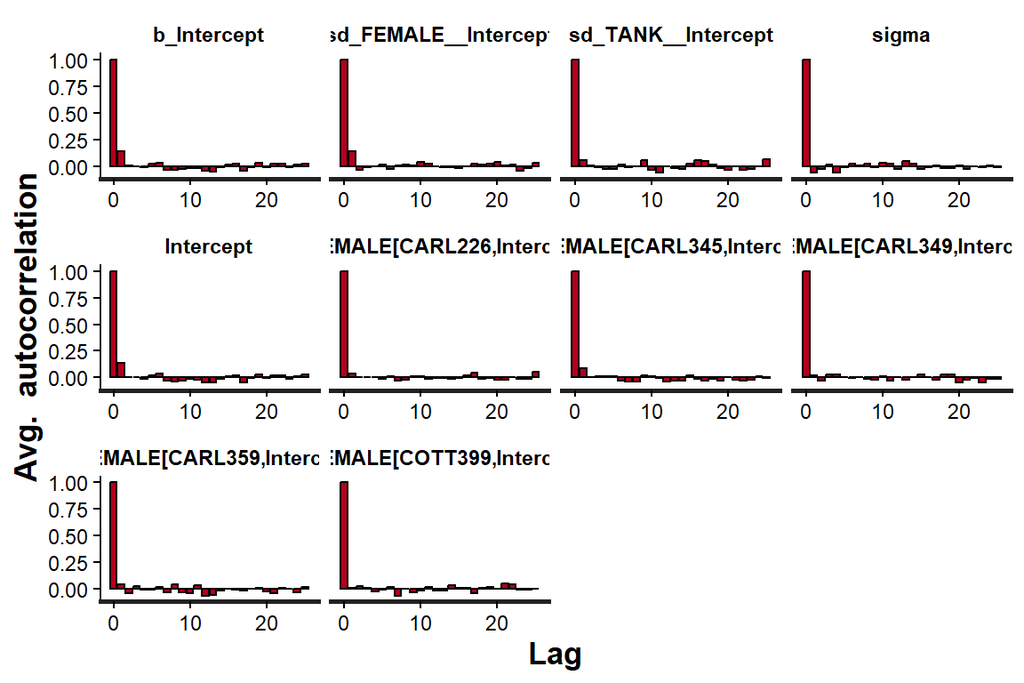

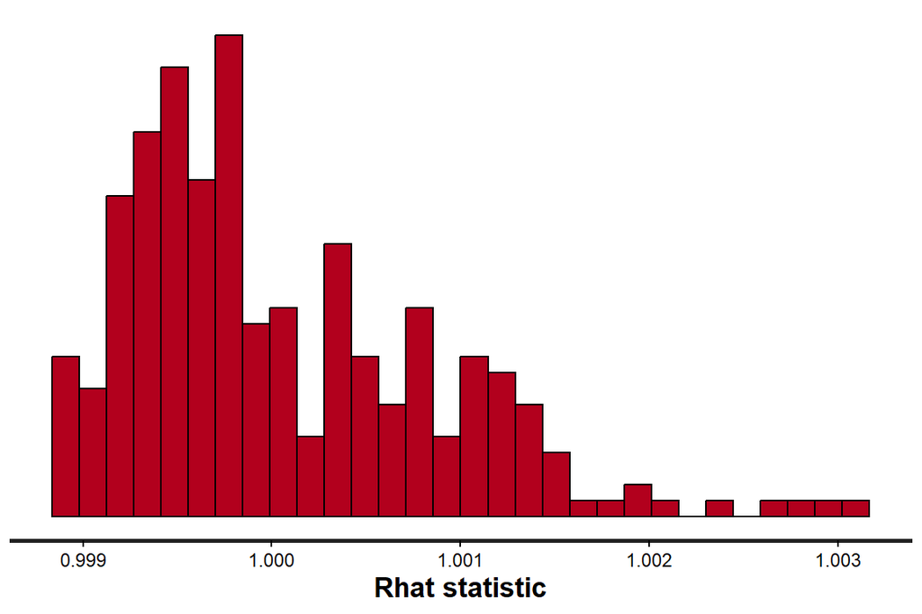

```r
stan_rhat(model.re0.2 $fit)
```

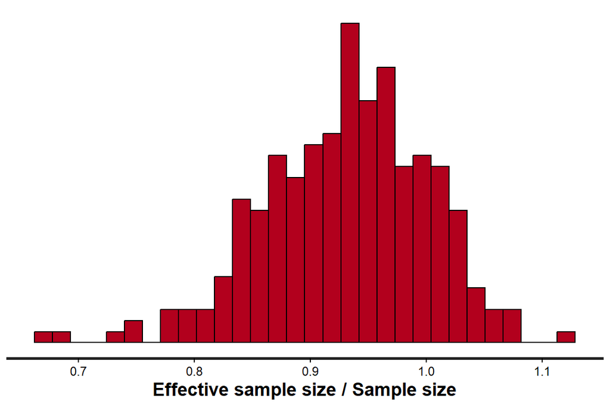

```r
stan_ess(model.re0.2 $fit)
```

```r
stan_dens(model.re0.2 $fit, separate_chains = TRUE)
```

```
## 'pars' not specified. Showing first 10 parameters by default.
```

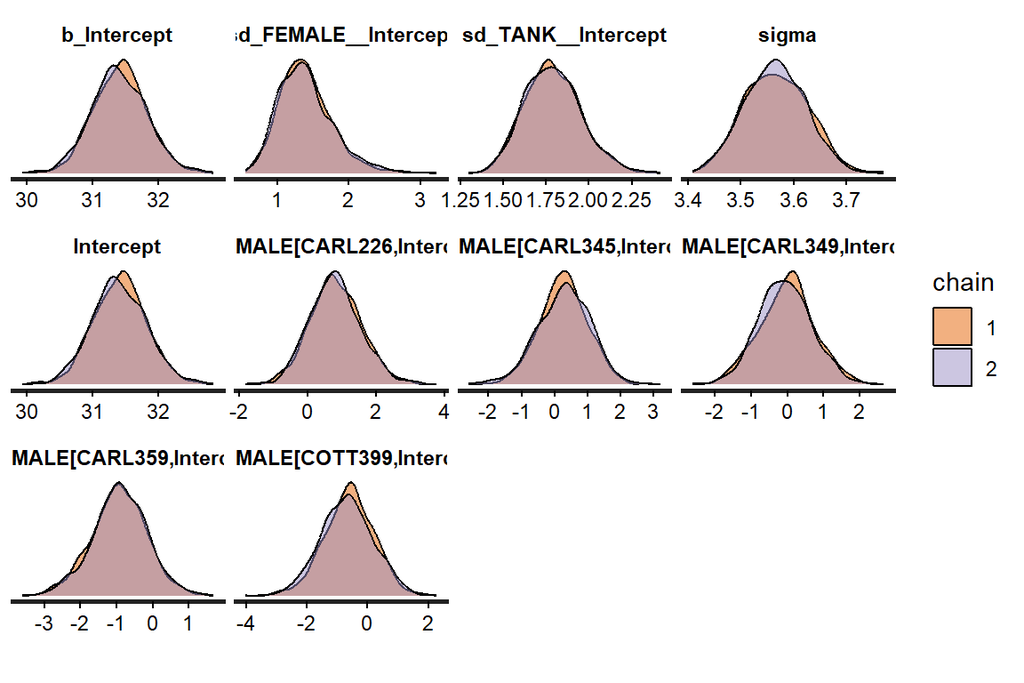

### {-}

## Model-3

### Priors

```r
model.re0.formula <- bf(LENGTH ~ 1 + (1|TANK) + (1|FEMALE) + (1|POPULATION))
get_prior(model.re.formula, data=growth3)
```

| prior | class | coef | group | resp | dpar | nlpar | lb | ub | tag | source |
| --- | --- | --- | --- | --- | --- | --- | --- | --- | --- | --- |
| student_t(3, 31.4, 3.8) | Intercept |  |  |  |  |  |  |  |  | default |
| student_t(3, 0, 3.8) | sd |  |  |  |  |  | 0 |  |  | default |
|  | sd |  | FEMALE |  |  |  |  |  |  | default |
|  | sd | Intercept | FEMALE |  |  |  |  |  |  | default |
|  | sd |  | LEVEL |  |  |  |  |  |  | default |
|  | sd | Intercept | LEVEL |  |  |  |  |  |  | default |
|  | sd |  | LEVEL:TANK |  |  |  |  |  |  | default |
|  | sd | Intercept | LEVEL:TANK |  |  |  |  |  |  | default |
|  | sd |  | POPULATION |  |  |  |  |  |  | default |
|  | sd | Intercept | POPULATION |  |  |  |  |  |  | default |

[output cut: 1 more lines]

```r
growth.priors <- prior(normal(31.4, 1.5), class="Intercept") +
  prior(student_t(3, 0, 4.4), class = "sigma")
```

### Model 3

```r
model.re0 <- brm(model.re0.formula,
              data = growth3,
              prior = growth.priors,
              warmup = 500,
              iter = 5000,
              seed=123,
              cores=2,
              save_pars = save_pars(all=TRUE),
              sample_prior = "yes",
              chains = 2,
              thin = 5,
              control = list(adapt_delta=0.95))
prior_summary(model.re0)
```

| prior | class | coef | group | resp | dpar | nlpar | lb | ub | source |
| --- | --- | --- | --- | --- | --- | --- | --- | --- | --- |
| normal(31.4, 1.5) | Intercept |  |  |  |  |  |  |  | user |
| student_t(3, 0, 3.8) | sd |  |  |  |  |  | 0 |  | default |
|  | sd |  | FEMALE |  |  |  |  |  | default |
|  | sd | Intercept | FEMALE |  |  |  |  |  | default |
|  | sd |  | POPULATION |  |  |  |  |  | default |
|  | sd | Intercept | POPULATION |  |  |  |  |  | default |
|  | sd |  | TANK |  |  |  |  |  | default |
|  | sd | Intercept | TANK |  |  |  |  |  | default |
| student_t(3, 0, 4.4) | sigma |  |  |  |  |  | 0 |  | user |

```r
saveRDS(model.re, file="./01.growth_data_analysis_files/model.re0.length.RDS")
```

### model validation

```r
stan_trace(model.re0$fit)
```

```
## 'pars' not specified. Showing first 10 parameters by default.
```

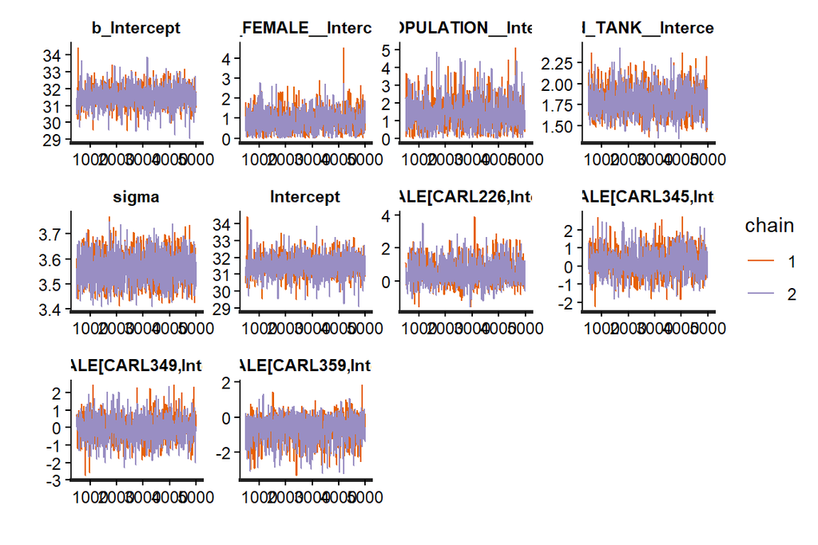

```r
stan_ac(model.re0$fit)
```

```
## 'pars' not specified. Showing first 10 parameters by default.
```

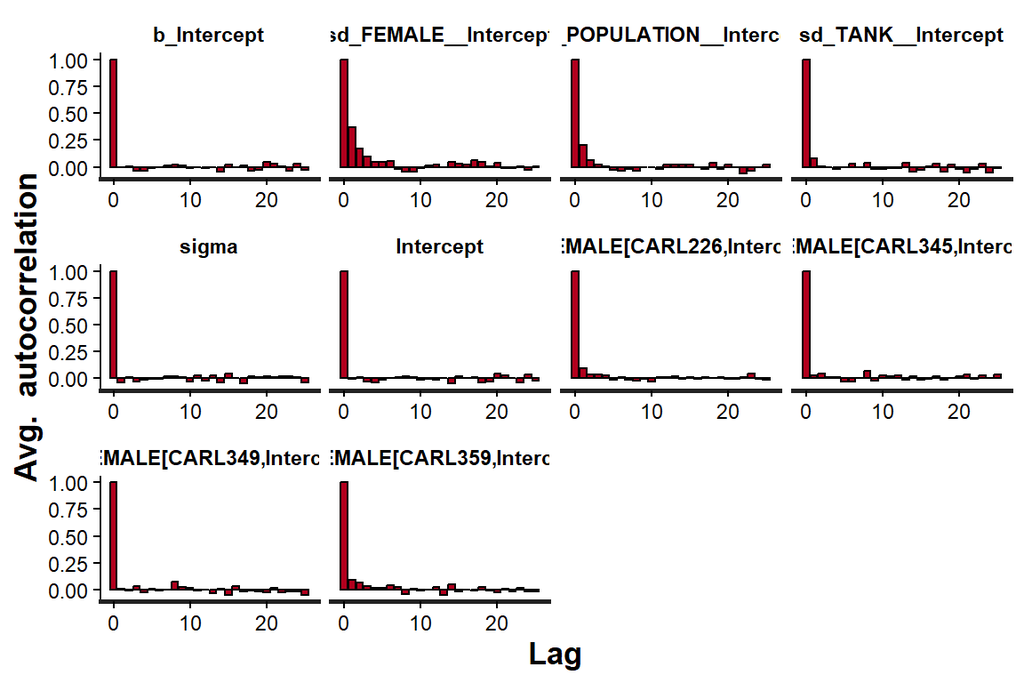

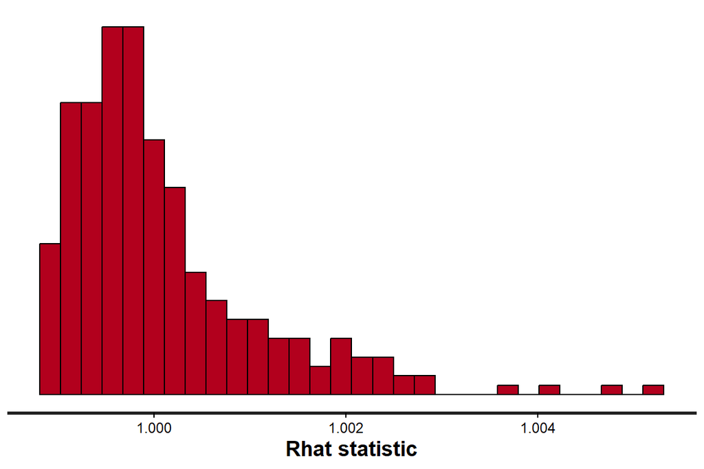

```r
stan_rhat(model.re0$fit)
```

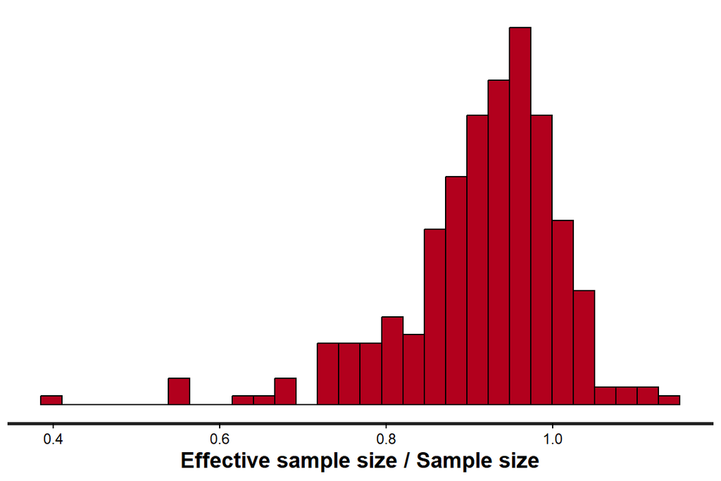

```r
stan_ess(model.re0$fit)
```

```r
stan_dens(model.re0$fit, separate_chains = TRUE)
```

```
## 'pars' not specified. Showing first 10 parameters by default.
```

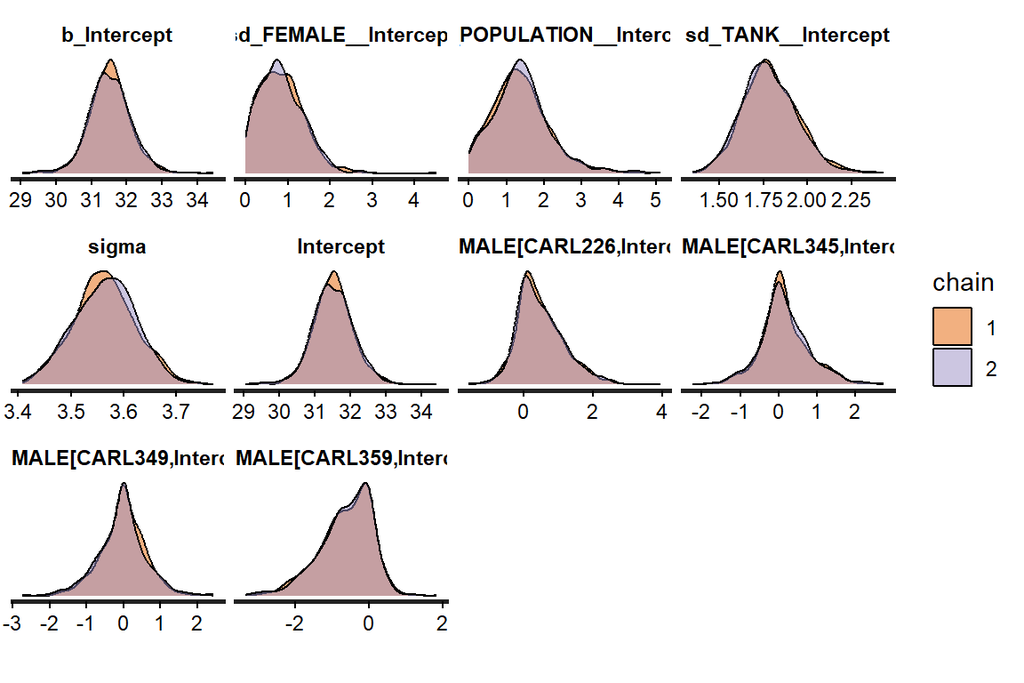

## Model-4

### Priors

```r
model.re2.formula <- bf(LENGTH ~ 1 + (1|LEVEL/TANK) + (1|POPULATION) + (1|FEMALE) + (1|CLUTCH_ORDER))
get_prior(model.re.formula, data=growth3)
```

| prior | class | coef | group | resp | dpar | nlpar | lb | ub | tag | source |
| --- | --- | --- | --- | --- | --- | --- | --- | --- | --- | --- |
| student_t(3, 31.4, 3.8) | Intercept |  |  |  |  |  |  |  |  | default |
| student_t(3, 0, 3.8) | sd |  |  |  |  |  | 0 |  |  | default |
|  | sd |  | FEMALE |  |  |  |  |  |  | default |
|  | sd | Intercept | FEMALE |  |  |  |  |  |  | default |
|  | sd |  | LEVEL |  |  |  |  |  |  | default |
|  | sd | Intercept | LEVEL |  |  |  |  |  |  | default |
|  | sd |  | LEVEL:TANK |  |  |  |  |  |  | default |
|  | sd | Intercept | LEVEL:TANK |  |  |  |  |  |  | default |
|  | sd |  | POPULATION |  |  |  |  |  |  | default |
|  | sd | Intercept | POPULATION |  |  |  |  |  |  | default |

[output cut: 1 more lines]

```r
growth.priors <- prior(normal(31.4, 1.5), class="Intercept") +
  prior(student_t(3, 0, 4.4), class = "sigma")
```

### Model-4

```r
model.re2 <- brm(model.re2.formula,
              data = growth3,
              prior = growth.priors,
              warmup = 500,
              iter = 5000,
              seed=123,
              cores=2,
              save_pars = save_pars(all=TRUE),
              sample_prior = "yes",
              chains = 2,
              thin = 5,
              control = list(adapt_delta=0.95))
prior_summary(model.re2)
```

| prior | class | coef | group | resp | dpar | nlpar | lb | ub | source |
| --- | --- | --- | --- | --- | --- | --- | --- | --- | --- |
| normal(31.4, 1.5) | Intercept |  |  |  |  |  |  |  | user |
| student_t(3, 0, 3.8) | sd |  |  |  |  |  | 0 |  | default |
|  | sd |  | CLUTCH_ORDER |  |  |  |  |  | default |
|  | sd | Intercept | CLUTCH_ORDER |  |  |  |  |  | default |
|  | sd |  | FEMALE |  |  |  |  |  | default |
|  | sd | Intercept | FEMALE |  |  |  |  |  | default |
|  | sd |  | LEVEL |  |  |  |  |  | default |
|  | sd | Intercept | LEVEL |  |  |  |  |  | default |
|  | sd |  | LEVEL:TANK |  |  |  |  |  | default |
|  | sd | Intercept | LEVEL:TANK |  |  |  |  |  | default |

[output cut: 3 more lines]

```r
saveRDS(model.re, file="./01.growth_data_analysis_files/model.re2.length.RDS")
```

### model validation

```r
stan_trace(model.re2$fit)
```

```
## 'pars' not specified. Showing first 10 parameters by default.
```

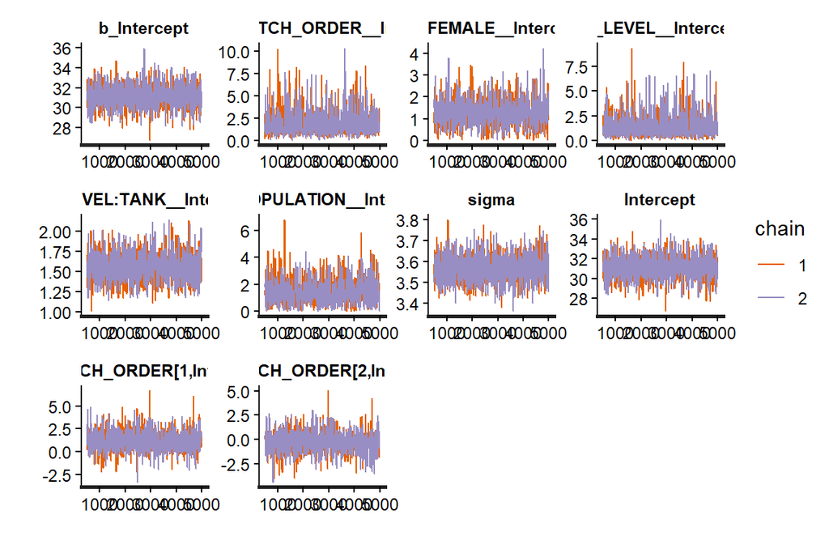

```r
stan_ac(model.re2$fit)
```

```
## 'pars' not specified. Showing first 10 parameters by default.
```

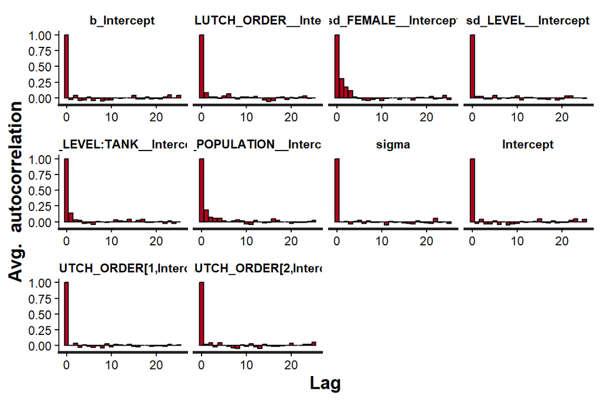

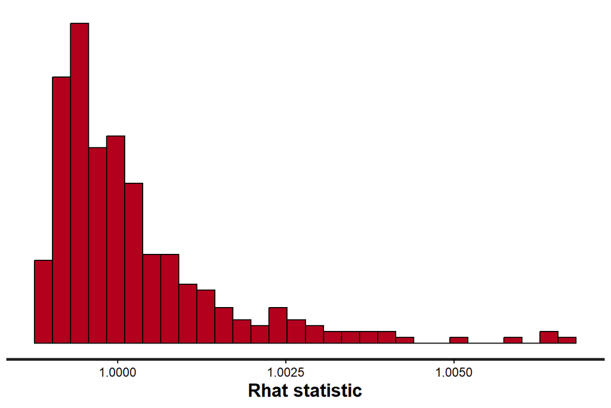

```r
stan_rhat(model.re2$fit)
```

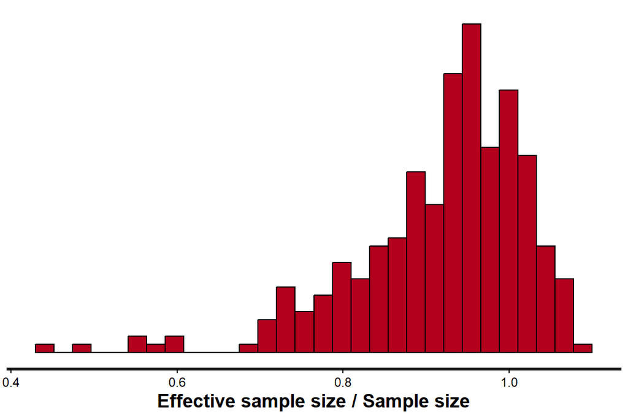

```r
stan_ess(model.re2$fit)
```

```r
stan_dens(model.re2$fit, separate_chains = TRUE)
```

```
## 'pars' not specified. Showing first 10 parameters by default.
```

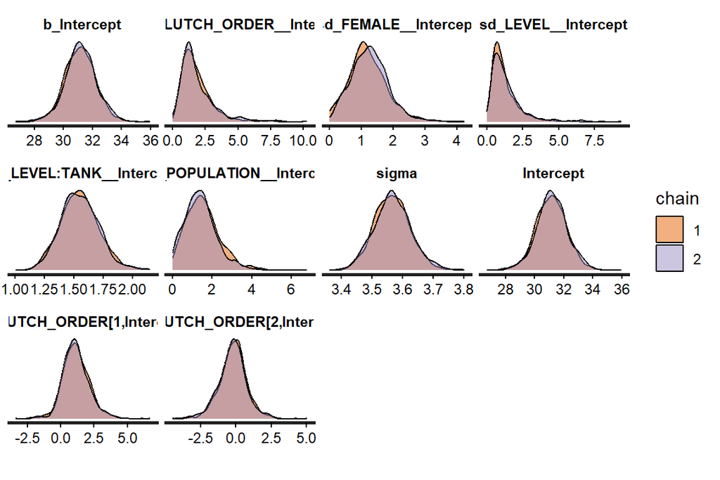

## LOO

```r
LOO(model.re0,model.re, model.re2,model.re0.2)
```

```
## Output of model 'model.re0':
##
## Computed from 1800 by 1961 log-likelihood matrix.
##
##          Estimate   SE
## elpd_loo  -5323.4 40.1
## p_loo        93.0  3.8
## looic     10646.7 80.2
## ------
## MCSE of elpd_loo is 0.3.
## MCSE and ESS estimates assume MCMC draws (r_eff in [0.7, 1.2]).
##
## All Pareto k estimates are good (k < 0.69).
## See help('pareto-k-diagnostic') for details.
##
## Output of model 'model.re':
##
## Computed from 1800 by 1961 log-likelihood matrix.
##
##          Estimate   SE
## elpd_loo  -5322.2 40.0
## p_loo        90.8  3.7
## looic     10644.5 80.0
## ------
## MCSE of elpd_loo is 0.3.
## MCSE and ESS estimates assume MCMC draws (r_eff in [0.7, 1.1]).
##
## All Pareto k estimates are good (k < 0.69).
## See help('pareto-k-diagnostic') for details.
##
## Output of model 'model.re2':
##
## Computed from 1800 by 1961 log-likelihood matrix.
##
##          Estimate   SE
## elpd_loo  -5322.0 40.1
## p_loo        89.7  3.7
## looic     10644.0 80.2
## ------
## MCSE of elpd_loo is 0.3.
```

[output cut: 11 more lines]

```
## p_loo        93.2  3.9
## looic     10647.4 80.3
## ------
## MCSE of elpd_loo is 0.3.
## MCSE and ESS estimates assume MCMC draws (r_eff in [0.6, 1.2]).
##
## All Pareto k estimates are good (k < 0.69).
## See help('pareto-k-diagnostic') for details.
##
## Model comparisons:
##             elpd_diff se_diff
## model.re2    0.0       0.0
## model.re    -0.2       1.3
## model.re0   -1.4       1.9
## model.re0.2 -1.7       1.8
```

First we will place random factors only within out model and see if they do a good job explaining the variance within our model. We will also be include priors which will be based off of out length data.

Model seems to perform well enough. There is one or two bars below the effective sample size cut off. But this will likely get smoothed out with more iterations and chains. Also it is very few samples. Lets start adding fixed factors.

# Fit mode [fixed factors]

Great lets start to fit our models. There are number of variables within our data frame some of which may or may not be important. To investigate which variables are important and which are not will test different hypotheses that use different combinations of variables that are suited to answer reasonable hypotheses.

We will start modelling the standard length of juveniles.

First we will test 3 different hypotheses as described below in more detail. All hypotheses-testing models will have **LENGTH** as the response variable as well as **DEV_TEMP** and **DENSITY** as independent variables. Note that each model will contain the random factors that were previously determined to explain the most variance in the previous step.

1. The first model tested, the **basic** model, forms aims to understand the influence of **DEV_TEMP** and **DENSITY** on juvenile fish length, additional co-variates **FEMALE_STANDARD_LENGTH**, **DENSITY** (of their holding tank), and **AGE** will be included because they can have an effect on juvenile growth.

```r
LENGTH ~ DEV_TEMP + FEMALE_STANDARD_LENGTH + DENSITY + AGE + {random factors}
```

2. The second model is based around the clutch/maternal conditions. Additional variables will include **FEMALE_STANDARD_LENGTH**, **DAYS_IN_TEMPERATURE** -applies to parents, **EGG_COUNT**. The idea of this hypothesis is that offspring length may be determined by early life conditions such as the size of the mother, how long the mother was exposed to potentially stressful conditions, how wide or narrow reproductive energy was spread, as well as the potential ‘health’ (as indicated by hatching success) of the clutch.

```r
cLENGTH ~ DEV_TEMP + FEMALE_STANDARD_LENGTH + DENSITY + DAYS_IN_TREATMENT + EGG_COUNT + {random factors}
```

3. The last model is a geographic model and will include **FEMALE_STANDARD_LENGTH**, **FEMALE_LATITUDE**, and **DENSITY**. In all but a few cases the farther and mother are from the same reef, therefore **FEMALE_LATITUDE** should be the same as **MALE_LATITUDE**. In the event that maternal and paternal sources were from different reefs, both parents would have come from similar latitudes. **POPULATION** was not included as it caused convergence issues, potentially due to the limited sample size from different populations.

```r
cLENGTH ~ DEV_TEMP*REGION + FEMALE_STANDARD_LENGTH + DENSITY + FEMALE_LAT + {random factors}
```

Once these models are run will be investigate their summary statistics to determine which factors were/were not deemed to have an impact on variation explained. Further models containing combinations of variables may also be explored depending on results.

Also because we are doing Bayesian modelling we will be listing priors. Our length data is normally distributed as shown in some of the exploratory data analysis plots. We can confirm this assumption during the model validation stage as well.

# Prior investigation

```r
growth3 |>
  group_by(REGION,DEV_TEMP) |>
  summarise(mean(na.omit(LENGTH)),
            sd(na.omit(LENGTH)))
```

```
## `summarise()` has regrouped the output.
## ℹ Summaries were computed grouped by REGION and DEV_TEMP.
## ℹ Output is grouped by REGION.
## ℹ Use `summarise(.groups = "drop_last")` to silence this message.
## ℹ Use `summarise(.by = c(REGION, DEV_TEMP))` for per-operation grouping
##   (`?dplyr::dplyr_by`) instead.
```

| REGION | DEV_TEMP | mean(na.omit(LENGTH)) | sd(na.omit(LENGTH)) |
| --- | --- | --- | --- |
| core | 28.5 | 32.46178 | 4.182013 |
| core | 30 | 31.33622 | 3.898145 |
| core | 31.5 | 30.18239 | 4.401018 |
| leading | 28.5 | 31.60271 | 4.214717 |
| leading | 30 | 31.96679 | 3.908585 |
| leading | 31.5 | 30.20092 | 3.577922 |

# Fit Models

## Basic model

### Priors

```r
model1.formula <- bf(LENGTH ~ DEV_TEMP*REGION +
                      scale(FEMALE_STANDARD_LENGTH, center=TRUE, scale=TRUE) +
                      scale(DENSITY, center=TRUE, scale=TRUE) +
                      scale(AGE_DAYS, center=TRUE, scale=TRUE)+
                      (1|TANK) +  (1|FEMALE) ,
              family=gaussian())
get_prior(model1.formula, data=growth3)
```

| prior | class | coef | group | resp | dpar | nlpar | lb | ub | tag | source |
| --- | --- | --- | --- | --- | --- | --- | --- | --- | --- | --- |
|  | b |  |  |  |  |  |  |  |  | default |
|  | b | DEV_TEMP30 |  |  |  |  |  |  |  | default |
|  | b | DEV_TEMP30:REGIONleading |  |  |  |  |  |  |  | default |
|  | b | DEV_TEMP31.5 |  |  |  |  |  |  |  | default |
|  | b | DEV_TEMP31.5:REGIONleading |  |  |  |  |  |  |  | default |
|  | b | REGIONleading |  |  |  |  |  |  |  | default |
|  | b | scaleAGE_DAYScenterEQTRUEscaleEQTRUE |  |  |  |  |  |  |  | default |
|  | b | scaleDENSITYcenterEQTRUEscaleEQTRUE |  |  |  |  |  |  |  | default |
|  | b | scaleFEMALE_STANDARD_LENGTHcenterEQTRUEscaleEQTRUE |  |  |  |  |  |  |  | default |
| student_t(3, 31.4, 3.8) | Intercept |  |  |  |  |  |  |  |  | default |

[output cut: 6 more lines]

```r
growth.priors <- prior(normal(31.4, 1.5), class="Intercept") +
  prior(normal(0, 1.5), class="b") +
  prior(student_t(3, 0, 4.4), class = "sigma")
```

### Basic model

```r
model1 <- brm(model1.formula,
              data = growth3,
              prior = growth.priors,
              warmup = 500,
              iter = 5000,
              seed=123,
              cores=2,
              save_pars = save_pars(all=TRUE),
              sample_prior = "yes",
              chains = 2,
              thin = 5,
              control = list(adapt_delta=0.95))
prior_summary(model1)
```

| prior | class | coef | group | resp | dpar | nlpar | lb | ub | tag | source |
| --- | --- | --- | --- | --- | --- | --- | --- | --- | --- | --- |
| normal(0, 1.5) | b |  |  |  |  |  |  |  |  | user |
|  | b | DEV_TEMP30 |  |  |  |  |  |  |  | default |
|  | b | DEV_TEMP30:REGIONleading |  |  |  |  |  |  |  | default |
|  | b | DEV_TEMP31.5 |  |  |  |  |  |  |  | default |
|  | b | DEV_TEMP31.5:REGIONleading |  |  |  |  |  |  |  | default |
|  | b | REGIONleading |  |  |  |  |  |  |  | default |
|  | b | scaleAGE_DAYScenterEQTRUEscaleEQTRUE |  |  |  |  |  |  |  | default |
|  | b | scaleDENSITYcenterEQTRUEscaleEQTRUE |  |  |  |  |  |  |  | default |
|  | b | scaleFEMALE_STANDARD_LENGTHcenterEQTRUEscaleEQTRUE |  |  |  |  |  |  |  | default |
| normal(31.4, 1.5) | Intercept |  |  |  |  |  |  |  |  | user |

[output cut: 6 more lines]

```r
saveRDS(model1, file="./01.growth_data_analysis_files/model1.length.RDS")
```

### stan plots

```r
stan_trace(model1$fit)
```

```
## 'pars' not specified. Showing first 10 parameters by default.
```

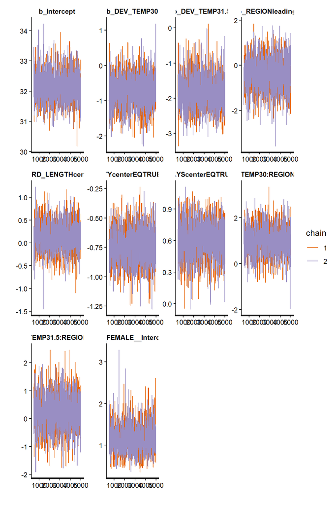

```r
stan_ac(model1$fit)
```

```
## 'pars' not specified. Showing first 10 parameters by default.
```

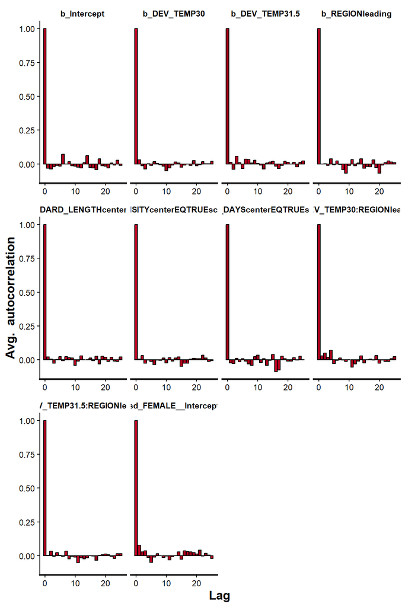

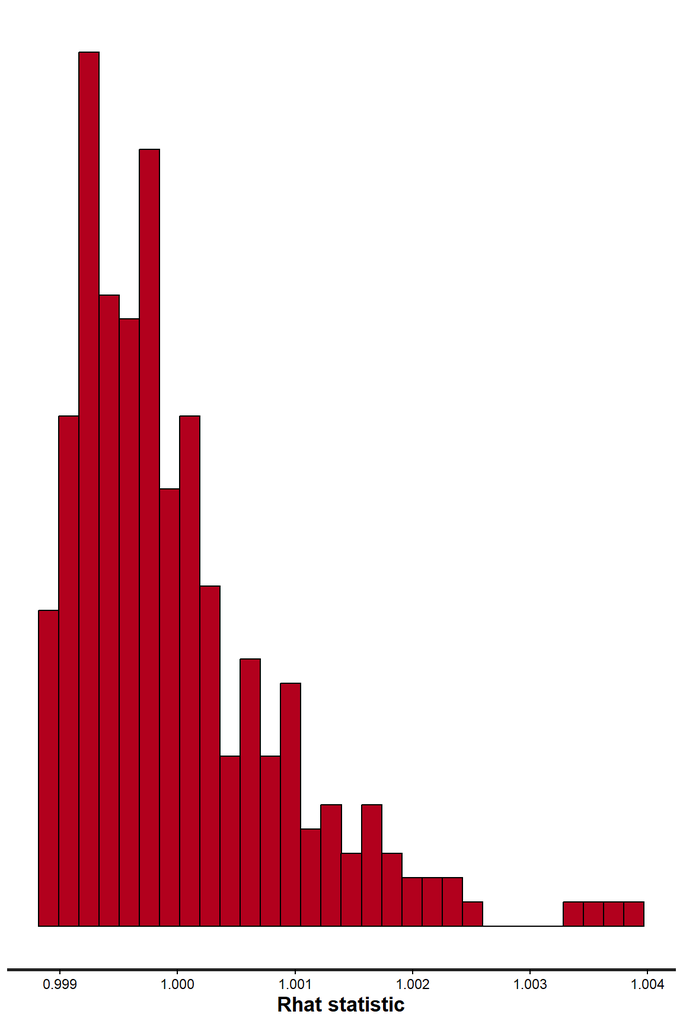

```r
stan_rhat(model1$fit)
```

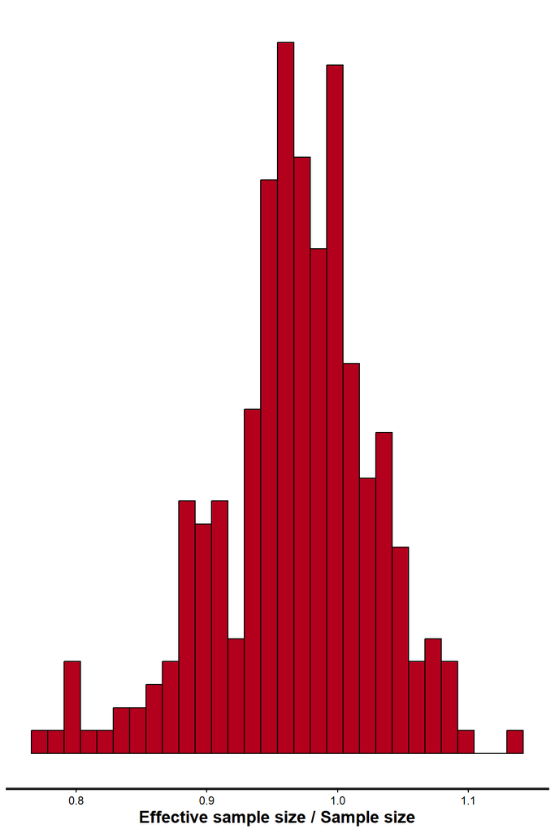

```r
stan_ess(model1$fit)
```

```r
stan_dens(model1$fit, separate_chains = TRUE)
```

```
## 'pars' not specified. Showing first 10 parameters by default.
```

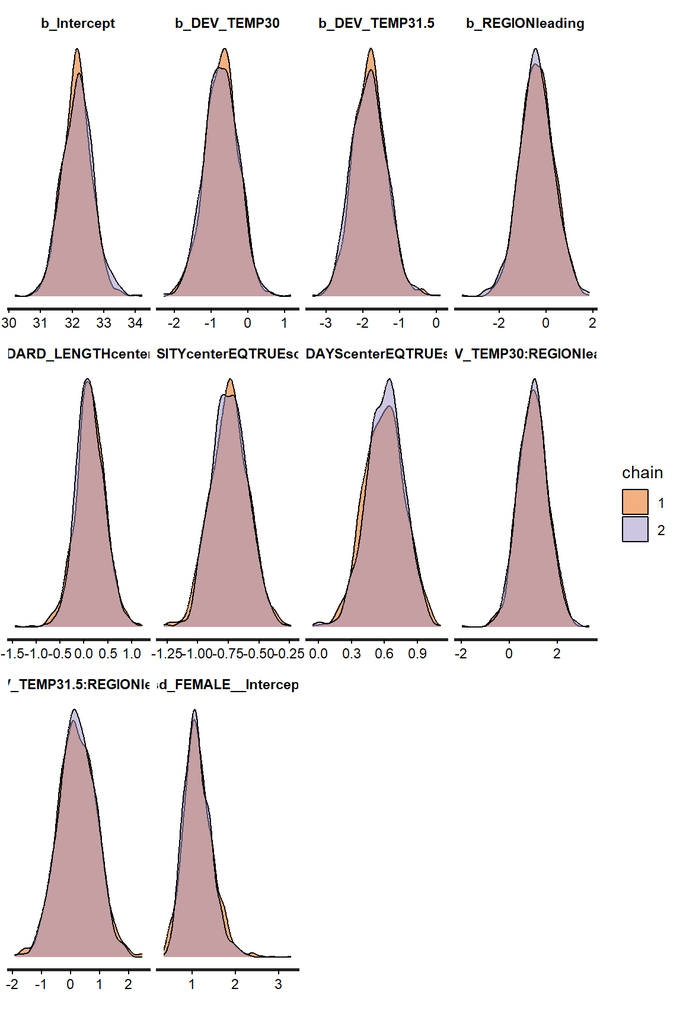

## Maternal effects model

### Priors

```r
model.mat.formula <- bf(LENGTH ~ DEV_TEMP*REGION +
                      scale(FEMALE_STANDARD_LENGTH, center=TRUE, scale=TRUE) +
                      scale(DENSITY, center=TRUE, scale=TRUE) +
                      scale(AGE_DAYS, center=TRUE, scale=TRUE)+
                      scale(DAYS_IN_TREATMENT, center=TRUE, scale=TRUE)+
                      scale(EGG_COUNT, center=TRUE, scale=TRUE) +
                      (1|TANK) +  (1|FEMALE),
              family=gaussian())
get_prior(model1.formula, data=growth3)
```

| prior | class | coef | group | resp | dpar | nlpar | lb | ub | tag | source |
| --- | --- | --- | --- | --- | --- | --- | --- | --- | --- | --- |
|  | b |  |  |  |  |  |  |  |  | default |
|  | b | DEV_TEMP30 |  |  |  |  |  |  |  | default |
|  | b | DEV_TEMP30:REGIONleading |  |  |  |  |  |  |  | default |
|  | b | DEV_TEMP31.5 |  |  |  |  |  |  |  | default |
|  | b | DEV_TEMP31.5:REGIONleading |  |  |  |  |  |  |  | default |
|  | b | REGIONleading |  |  |  |  |  |  |  | default |
|  | b | scaleAGE_DAYScenterEQTRUEscaleEQTRUE |  |  |  |  |  |  |  | default |
|  | b | scaleDENSITYcenterEQTRUEscaleEQTRUE |  |  |  |  |  |  |  | default |
|  | b | scaleFEMALE_STANDARD_LENGTHcenterEQTRUEscaleEQTRUE |  |  |  |  |  |  |  | default |
| student_t(3, 31.4, 3.8) | Intercept |  |  |  |  |  |  |  |  | default |

[output cut: 6 more lines]

```r
growth.priors <- prior(normal(31.4, 1.5), class="Intercept") +
  prior(normal(0, 1.5), class="b") +
  prior(student_t(3, 0, 4.4), class = "sigma")
```

```r
model.mat <- brm(model.mat.formula,
              family=gaussian(),
              data = growth3,
              warmup = 500,
              iter = 5000,
              seed=123,
              cores=2,
              save_pars = save_pars(all=TRUE),
              chains = 2,
              thin = 5,
              control = list(adapt_delta=0.95))
prior_summary(model.mat)
```

| prior | class | coef | group | resp | dpar | nlpar | lb | ub | source |
| --- | --- | --- | --- | --- | --- | --- | --- | --- | --- |
|  | b |  |  |  |  |  |  |  | default |
|  | b | DEV_TEMP30 |  |  |  |  |  |  | default |
|  | b | DEV_TEMP30:REGIONleading |  |  |  |  |  |  | default |
|  | b | DEV_TEMP31.5 |  |  |  |  |  |  | default |
|  | b | DEV_TEMP31.5:REGIONleading |  |  |  |  |  |  | default |
|  | b | REGIONleading |  |  |  |  |  |  | default |
|  | b | scaleAGE_DAYScenterEQTRUEscaleEQTRUE |  |  |  |  |  |  | default |
|  | b | scaleDAYS_IN_TREATMENTcenterEQTRUEscaleEQTRUE |  |  |  |  |  |  | default |
|  | b | scaleDENSITYcenterEQTRUEscaleEQTRUE |  |  |  |  |  |  | default |
|  | b | scaleEGG_COUNTcenterEQTRUEscaleEQTRUE |  |  |  |  |  |  | default |

[output cut: 14 more lines]

```r
saveRDS(model.mat, file="./01.growth_data_analysis_files/model.maternal.length.RDS")
```